# Data-Science-871-JHPretorius-Project

JH Pretorius

2023-05-24

# Preface

```r
# goal: "Threefold: (1) Transformation and cleaning of data. (2) Exploratory Data Analysis of Dating Site Data. (3) Machine Learning modelling."

# Clear environment
rm(list = ls())
options(scipen = 999)

# Load packages in use
pacman::p_load(dplyr, ggplot2, tidyverse, rsample, caret, glmnet, vip, pdp, stringr,
               tidytext, emoji, stopwords, ggridges, wordcloud2, ggmap, readxl, maps,
               viridis, eurostat, corrplot, GGally, reshape2, grid, ellipse, networkD3)

# Define plot themes and palettes
palette <- c("#1beaa7", "#00d9d3", "#00c2ff", "#00a5ff", "#007bff", "#8c2aef")

th <- theme(legend.position = "right",
            panel.background = element_blank(),
            plot.background = element_rect(fill = "#000123", color = "#000123"),
            panel.grid.major = element_line(color="white", size = 0.1),
            panel.grid.minor = element_line(color="white", size = 0.1),
            axis.title.x=element_text(colour="white", size = 12,
                                      family = "arial", vjust=-2,hjust=0.5, face = "bold"),
            axis.title.y=element_text(colour="white", size = 12,
                                      family = "arial",vjust = 3,hjust=0.5, face = "bold"),
            axis.text.y=element_text(colour ="white", size = 10,
                                     family = "arial"),
            axis.text.x=element_text(colour="white", size = 10,
                                     family = "arial"),
            plot.margin = unit(c(0.5,0.5,0.5,0.5), "cm"),
            plot.title = element_text(colour="white", size = 16,
                                      family = "arial",hjust=0.5, face = "bold"),
            plot.subtitle = element_text(colour="white", size = 14,
                                         family = "arial"),
            plot.caption = element_text(colour="white", size = 10,
                                        family = "arial"),
            legend.text = element_text(colour="white", size = 12,
                                       family = "arial"),
            legend.title = element_text(colour="white", size = 12,
                                        family = "arial", hjust=3, face = "bold"),
            axis.ticks = element_blank(),
            strip.text = element_text(colour="white", size = 12,
                                      family = "arial", vjust=1,hjust=0.5),
            legend.key = element_rect(fill = "#000123", color = "#000123"),
            legend.background = element_rect(fill = "#000123"))

# Import data
path <- "/Users/janhendrikpretorius/Library/CloudStorage/OneDrive-StellenboschUniversity/Masters-2023/Modules/Data Science/DataScience-871-repo/JHPretorius-Project/Candidate Data Sets/Dating/"
file <- "lovoo_v3_users_api-results.csv"

df <- read_csv(paste0(path, file))
```

# Introduction

The objective of this study is to investigate the critical factors that contribute to an individual’s appeal, popularity, and recognition within an online dating platform. The data utilised for this research is sourced from Lovoo, a prominent European dating application, and is accessible via [Kaggle](https://www.kaggle.com/datasets/utkarshx27/lovoo-dating-app-dataset?select=lovoo_v3_users_api-results.csv).

The underlying motivation for this study stems from the desire to comprehend behavioural patterns that transcend the confines of physical attractiveness. The aim is to unveil hidden determinants that may shape interpersonal interactions within a digital dating platform. The behaviour exhibited on these platforms carries significance, even in economic contexts. By deciphering this behavioural paradigm, it can potentially contribute to the development of economic models. These enhanced models can subsequently offer a more profound analytic framework to elucidate overall mate-selection behaviour.

The initial phase of the analysis involves the transformation of raw data into a more interpretable format. This includes the creation of additional variables tailored to augment the predictive capacity of the statistical models employed in subsequent stages. This phase facilitates the exploratory aspect of the research, enabling an in-depth examination of data in search of potential predictor variables. The objective extends beyond understanding the phenomena; the aim is to anticipate which factors instigate an increased number of profile views and, subsequently, the ‘likes’ received.

The modelling process is a two-step approach. The first stage focuses on identifying variables that may elucidate why individuals view a certain profile. Potential variables include online presence, age, geographical location, and the timing of an individual’s online activity. The second stage aims to identify factors that influence the likelihood of a profile receiving ‘likes’. These may include the number of pictures on a profile, the characteristics of a profile’s biography, languages spoken, profile verification status, and mobile usage.

It is noteworthy that the number of ‘likes’ received by a profile strongly correlates with the number of views that profile has. Consequently, it may be necessary to use a two-stage model where the first stage models the factors influencing profile views, and the subsequent stage uses the outcomes from the first stage to model the likes received by a profile.

A random forest model is employed in this study due to its robust ability to discern intricate characteristics that influence human behaviour. The model serves as a guide towards achieving a comprehensive understanding of the determinants of attractiveness, popularity, and recognition in the digital dating arena.

# Part 1: Transformation and Cleaning

#### Head of dataframe

```
## # A tibble: 6 × 42
##   gender genderLooking   age name         counts_details counts_pictures
##   <lgl>  <chr>         <dbl> <chr>                 <dbl>           <dbl>
## 1 FALSE  M                25 daeni                  1                  4
## 2 FALSE  M                22 italiana 92            0.85               5
## 3 FALSE  M                21 Lauraaa                0                  4
## 4 FALSE  none             20 Qqkwmdowlo             0.12               3
## 5 FALSE  M                21 schaessie {3           0.15              12
## 6 FALSE  M                24 Baby dee               0.81              18
## # ℹ 36 more variables: counts_profileVisits <dbl>, counts_kisses <dbl>,
## #   counts_fans <dbl>, counts_g <dbl>, flirtInterests_chat <lgl>,
## #   flirtInterests_friends <lgl>, flirtInterests_date <lgl>, country <chr>,
## #   city <chr>, location <chr>, distance <dbl>, isFlirtstar <dbl>,
## #   isHighlighted <dbl>, isInfluencer <dbl>, isMobile <dbl>, isNew <dbl>,
## #   isOnline <dbl>, isVip <dbl>, lang_count <dbl>, lang_fr <lgl>,
## #   lang_en <lgl>, lang_de <lgl>, lang_it <lgl>, lang_es <lgl>, …
```

#### Table 1: Description of variables in data set.

| Variable | Description |
| --- | --- |
| `genderLooking` | Preferred gender the subject is looking to engage with. Represented as ‘M’ for male, ‘F’ for female, ‘both’ for male and female, or ‘none’. |
| `age` | Age of the individual. |
| `counts_details` | How complete the profile is. Proportion of detail in the account. Measured from 0.0-1.0. |
| `counts_pictures` | How many pictures does the profile contain. |
| `counts_profileVisits` | How many times the profile has been viewed. |
| `counts_kisses` | Number of ‘kisses’ or ‘likes’ received by profile. |
| `flirtInterests_*` | What the individual is interested in. ‘*’ represents: ‘chat’, ‘date’, ‘friends’. |
| `verified` | Whether the profile has been verified or not. |
| `lang_count` | Number of languages spoken by an individual. |
| `lang_*` | Language spoken by an individual. ‘*’ represents: ‘en’ (English), ‘de’ (German), ‘fr’ (French), ‘it’ (Italian), ‘es’ (Spanish). |
| `whazzup` | A phrase that represents the profile’s ‘bio’. |

The original dataset is already quite useable, but we can produce better models by adding some new variables. The first step is to take a closer look at the language people use in their profiles. I am focusing on two main things here: the words used in the profile descriptions, and the use of emojis. Both of these could give insights into the person’s confidence and desirability.

The code chunk below creates two new dummy variables, `has_emoji` and `contains_popular_word`. `has_emoji` attributes a ‘1’ based on whether `wazzup` contains an emoji. `contains_popular_word` attributes a ‘1’ based on whether `wazzup` contains a popular word. The code chunk also outputs which words are the most popular in a word cloud. (The word cloud is a dynamic image that shows the popularity when hovering over a specific word)

```r
# Define stop words for different languages
all_stop_words <- c(stopwords::stopwords("de"), stopwords::stopwords("en"), stopwords::stopwords("fr"))

# Define dummy variable that detects presence of emojis
# Also remove digits from 'whazzup' column
df <- df %>%
  mutate(has_emoji = ifelse(emoji_detect(whazzup), 1, 0),
         whazzup = str_remove_all(whazzup, "[[:digit:]]+"))

# Get the most used words in profile
# First, create a table of words with the corresponding counts_profileVisits
words_visits <- df %>%
  unnest_tokens(word, whazzup) %>%
  select(word, counts_profileVisits)

# Then calculate the mean counts_profileVisits for each word and its count
words <- words_visits %>%
  group_by(word) %>%
  summarise(mean_profileVisits = mean(counts_profileVisits, na.rm = TRUE),
            word_count = n(),
            .groups = "drop")

# Create word popularity index and determine popular words
words <- words %>%
  mutate(popularity_index = 0.8 * word_count + 0.2 * mean_profileVisits) %>%
  filter(popularity_index > 200 & word_count > 10,
         word != "",
         !is.na(word),
         !is.na(mean_profileVisits),
         !is.na(word_count),
         !is.na(popularity_index)) %>%
  filter(!word %in% all_stop_words)

# Create a single pattern string that matches any word in words$word
words_pattern <- paste(words$word, collapse = "|")

# Add the new variable to df
df <- df %>%
  mutate(contains_popular_word = ifelse(str_detect(whazzup, words_pattern), 1, 0)) %>%
  mutate(
    contains_popular_word = replace_na(contains_popular_word, 0),
    has_emoji = replace_na(has_emoji, 0)
  )

words <- words %>%
  arrange(desc(popularity_index)) %>%
  select(c(word, popularity_index))
```

#### Figure 1: Word cloud of popular words in bios.

[interactive chart not shown]

Interestingly, one may see that popular words (those are words that get many profile views and are used frequently), are social media tags. That is, individuals that have their social media details, such as their Instagram handle, Facebook name, and Snapchat handle, on their account tend to get more profile views. As such, I will create another variable, called `has_social` that captures whether a profile contains social media particulars. Due to endogeneity and possible multicollinearity between `contains_popular_word` and `has_social`, only one can be used in modelling. Whichever delivers the most accurate result will then be used.

```r
social <- "instagram|insta|facebook|fb|snapchat|snap"
df <- df %>%
  mutate(whazzup = tolower(whazzup),
         has_social = as.numeric(str_detect(whazzup, social))) %>%
  replace_na(list(has_social = 0))
```

Another operation pertains to the time an individual is online. I add a new dummy variable called `night_owl` to the dataframe based on whether a person was online at night or not. The motivation behind this is that dating apps tend to be more popular in the evenings, than during daytime.

```r
df <- df %>%
  mutate(night_owl = ifelse(hour(hms(substr(lastOnlineDate, 12, 19))) > 18 |
                            hour(hms(substr(lastOnlineDate, 12, 19))) < 6, 1, 0))
```

Finally, before kicking off with the exploratory data analysis, it might be fitting to standardise the following three variables: `counts_profileVisits`, `counts_kisses`, and `counts_pictures`. This operation may help to more clearly visualise how some variables influence each other.

```r
df$counts_profileVisitsStd <- scale(df$counts_profileVisits)
df$counts_kissesStd <- scale(df$counts_kisses)
df$counts_picturesStd <- scale(df$counts_pictures)
```

# Part 2: Exploratory Data Analysis

The goal of this section is to uncover relationships within the dataset. Starting off, a visual analysis of the different variables is conducted to assess their potential relevance. This is followed by a stepwise regression to help identify the variables that might lead to the most accurate model. However, it’s worth noting that the results of the stepwise regression should guide, but not entirely determine, the final model selection. Certain variables might not pass the ‘stepwise’ threshold, yet they might still hold valuable insights.

As alluded to in the introduction, it becomes clear that certain variables influence the number of likes, while others predominantly affect profile views. This distinction is particularly important because some profile characteristics are only observable when a profile is actually being viewed - a profile biography, for example. Nonetheless, a substantial correlation between profile views and likes is evident. This relationship is visually represented in Figure 2 below.

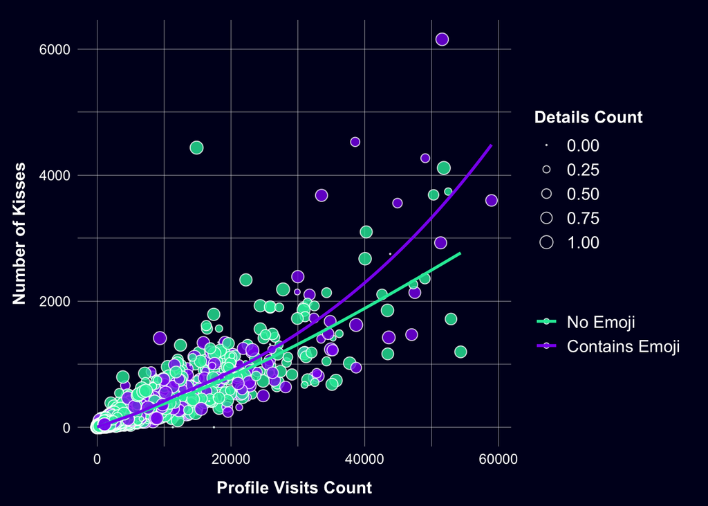

## Biography characteristics and popularity

#### Figure 3: Boxplots showing effects of profile characteristics on popularity. Left panel: effect of a bio containing social media particulars and/or an emoji on likes received. Right panel: effect of an online profile and/or being a night owl on number of profile visits.

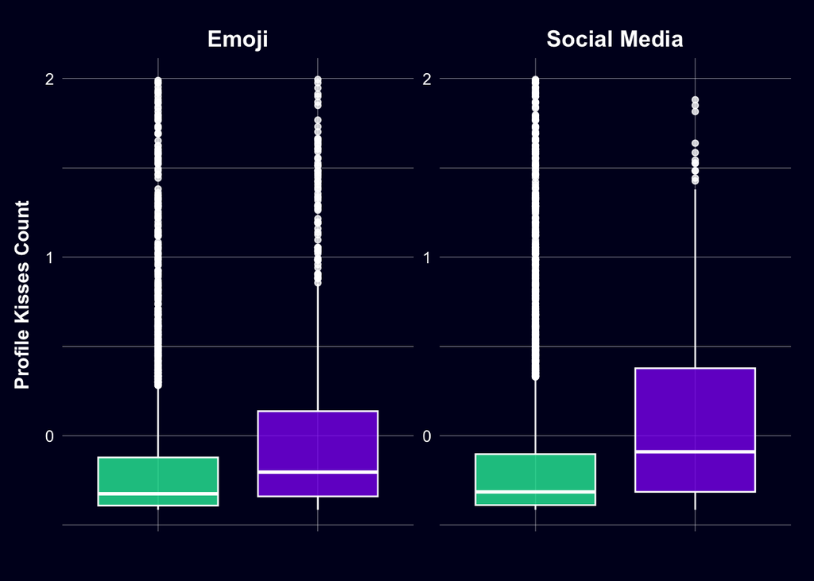

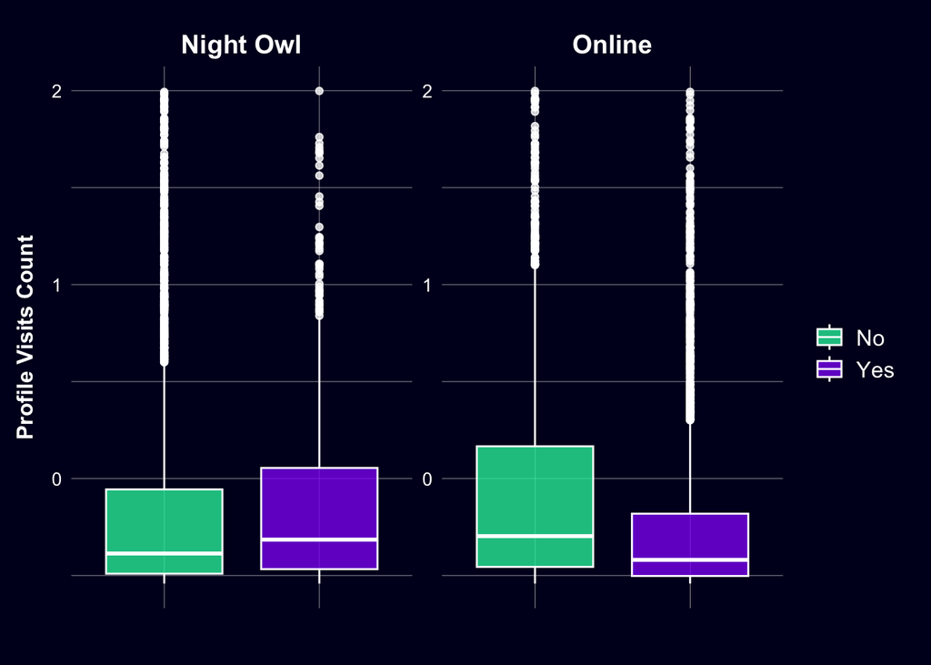

## Geographical characteristics and popularity

By using the Google Maps API, I was able to geocode the locations of every profile in the data. The goal is to visualise how location effects profile views. The code chunk below was used to geocode the data.

```r
# Note: commented out, due to costs associated with geocoding through the API
# df_city <- df %>%
#   select(c(city, country, counts_profileVisits)) %>%
#   mutate(address = paste0(city, ", ", country)) %>%
#   group_by(address) %>%
#   summarise(mean_profile_views = mean(counts_profileVisits, na.rm = TRUE))
#
# df_city <- df_city %>%
#   mutate(geocode_data = map(address, ~geocode(.x, source = "google", output = "latlon")),
#          lon = map_dbl(geocode_data, "lon"),
#          lat = map_dbl(geocode_data, "lat"))
#
# write_csv(df_city, "geocode_latlon.csv")
```

#### Figure 4: Geographic data visualisation of profile views. Size and colour of bubbles in top panel indicate profile views. Colour of country in the bottom panel indicate profile views.

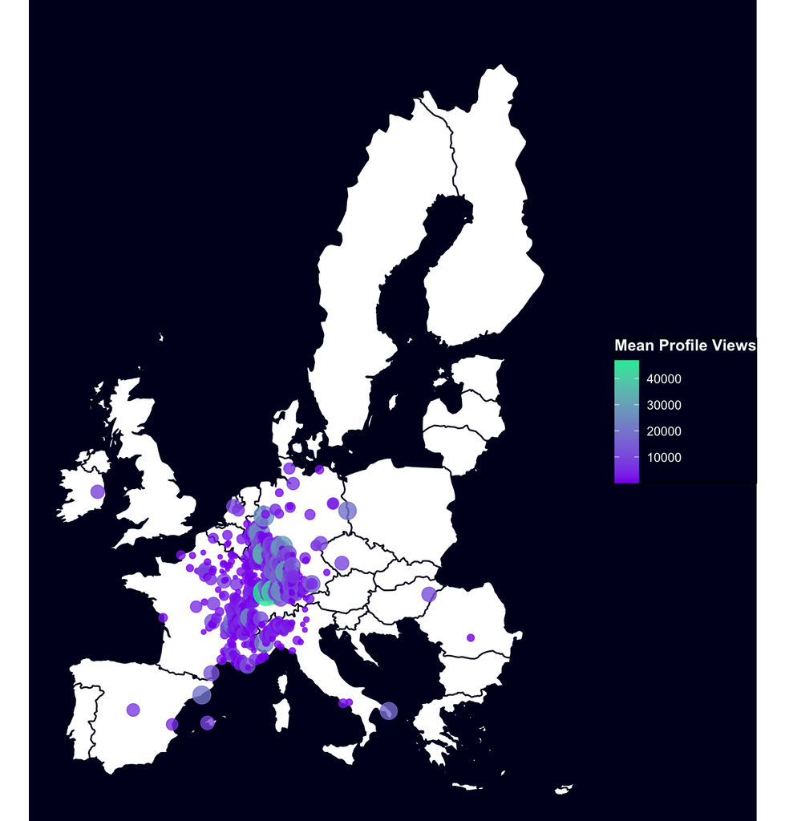

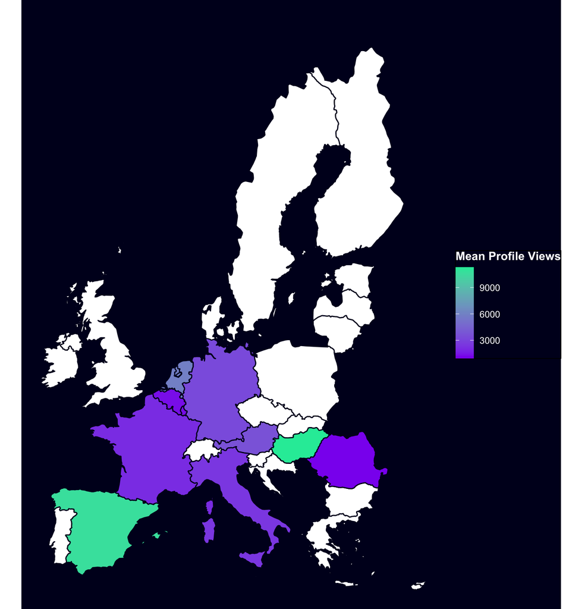

#### Figure 5: Lollipop chart of number of users by country. The colour of the lollipops indicate mean profile views.

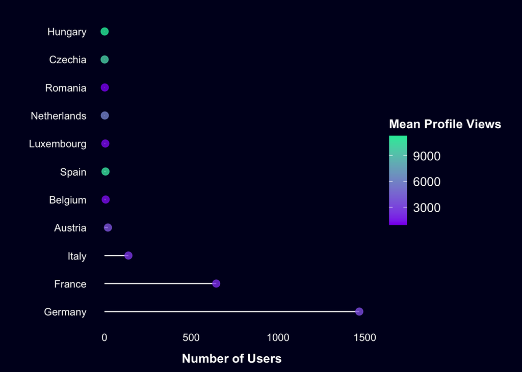

## Other profile characteristics and popularity

The goal of this section is to understand whether certain details on a profile affect popularity on a dating app.

#### Figure 6: Correlogram of profile characteristics and number of likes received.

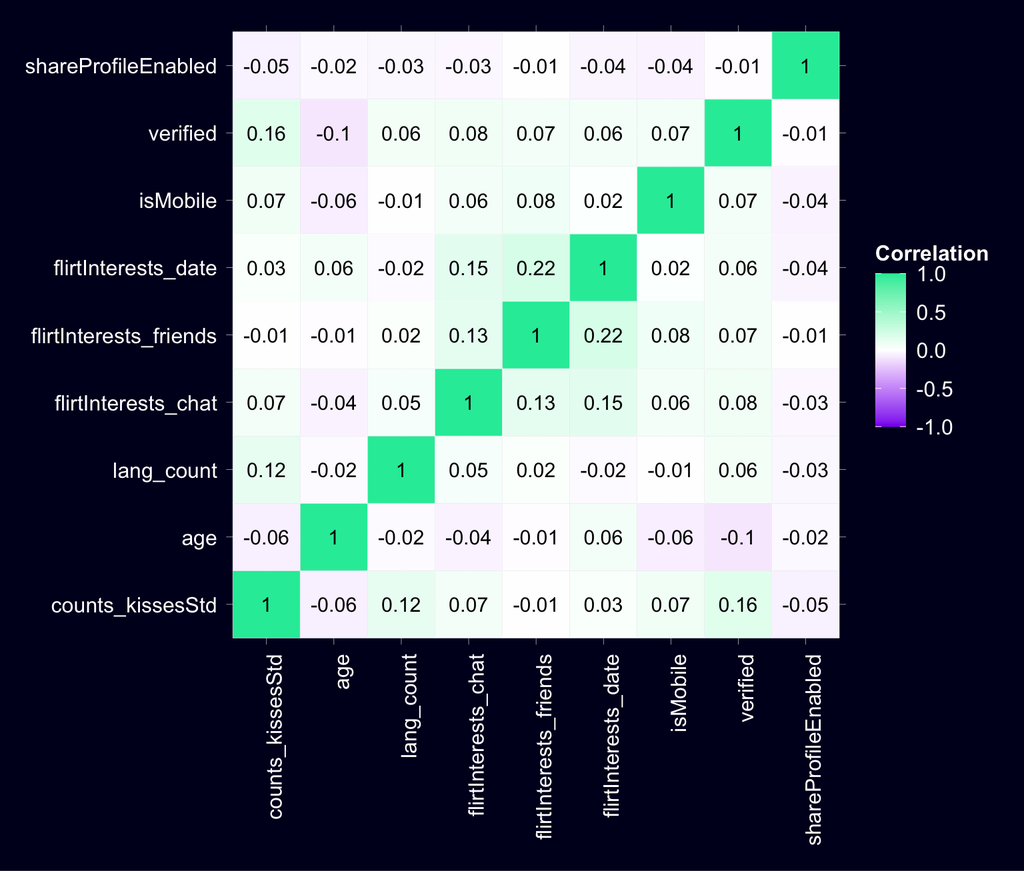

Language may also play a role in popularity. In figure 6 I accounted for this by acknowledging the number of languages spoken as a possible predictor of popularity. In figure 7 below I visualise the distribution of the number of likes received based on specific spoken languages.

#### Figure 7: Ridgeline plot of languages spoken and number of likes received. Dashed line shows overall mean profile likes.

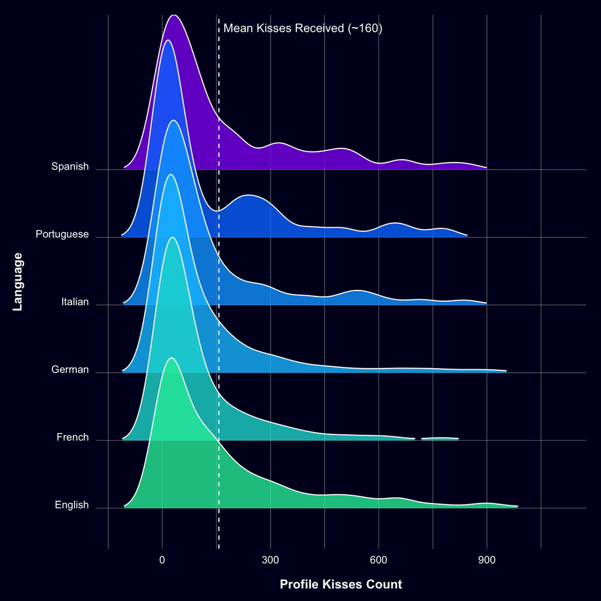

#### Figure 8: Dotted line plot of the number of pictures in profile and likes received. The mean number of likes received by number of photos was used to plot this relationship. Lines split based on social media tag presence in profile.

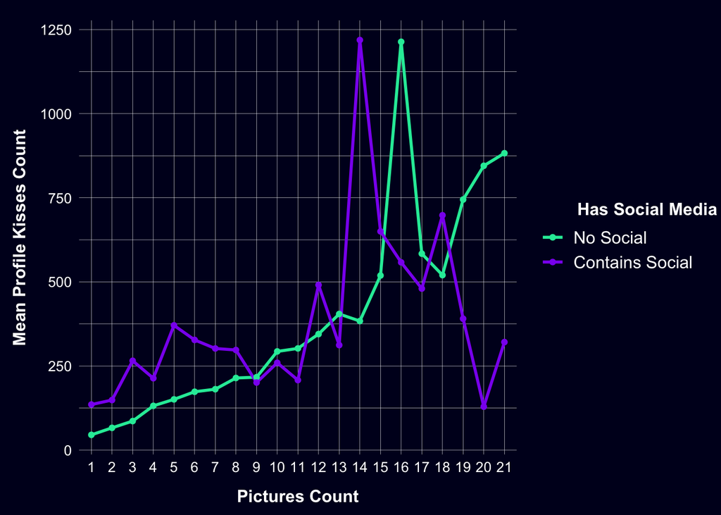

```r
df <- df %>%
  filter(!is.na(night_owl))
# Define full and null model
full.model <- lm(counts_kisses ~ counts_profileVisits + genderLooking + age + counts_details + counts_pictures + counts_fans +
                 flirtInterests_chat + flirtInterests_friends + flirtInterests_date + isFlirtstar + isHighlighted + isInfluencer + isMobile +
                   lang_count + lang_fr + lang_en + lang_de + verified + shareProfileEnabled + has_emoji + has_social + night_owl, data = df)
null.model <- lm(counts_kisses ~ 1, data = df)

# Perform stepwise regression
stepwise.model <- step(null.model, scope = list(lower = null.model, upper = full.model), direction = "both")
```

```
## Start:  AIC=47158.87
## counts_kisses ~ 1
##
##                          Df Sum of Sq       RSS   AIC
## + counts_profileVisits    1 446494007 122482059 41060
## + counts_pictures         1  77048455 491927611 46583
## + verified                1  15080267 553895799 47054
## + has_emoji               1   9416596 559559469 47095
## + counts_details          1   8999937 559976128 47098
## + counts_fans             1   8944052 560032014 47098
## + has_social              1   8907145 560068921 47098
## + lang_count              1   8153219 560822847 47104
## + isMobile                1   3077952 565898113 47139
## + lang_en                 1   3063555 565912511 47139
## + flirtInterests_chat     1   2689980 566286086 47142
## + lang_de                 1   2657055 566319010 47142
## + age                     1   1953493 567022573 47147
## + shareProfileEnabled     1   1588087 567387979 47150
## + lang_fr                 1    938055 568038011 47154
## + flirtInterests_date     1    600075 568375990 47157
## <none>                                568976066 47159
## + isFlirtstar             1    217471 568758595 47159
## + isHighlighted           1    217471 568758595 47159
## + night_owl               1     29789 568946277 47161
## + flirtInterests_friends  1     22844 568953222 47161
## + genderLooking           3    398879 568577187 47162
##
## Step:  AIC=41060.38
## counts_kisses ~ counts_profileVisits
##
##                          Df Sum of Sq       RSS   AIC
## + lang_de                 1   1675523 120806535 41008
## + lang_fr                 1   1330446 121151612 41019
## + verified                1    190874 122291185 41056
## + night_owl               1    115081 122366978 41059
## + age                     1    102022 122380037 41059
## <none>                                122482059 41060
## + flirtInterests_friends  1     54981 122427078 41061
## + counts_details          1     44303 122437755 41061
## + flirtInterests_date     1     41470 122440589 41061
```

[output cut: 163 more lines]

```
## + lang_count              1     28657 120148275 40998
## + isFlirtstar             1     20013 120156919 40998
## + isHighlighted           1     20013 120156919 40998
## + counts_details          1     16288 120160644 40998
## + counts_fans             1     10851 120166081 40999
## + shareProfileEnabled     1      3358 120173575 40999
## + counts_pictures         1      3108 120173825 40999
## + flirtInterests_chat     1      1140 120175792 40999
## + flirtInterests_date     1       351 120176581 40999
## + lang_en                 1       298 120176634 40999
## + has_emoji               1        39 120176893 40999
## - night_owl               1    169364 120346297 41001
## - age                     1    197863 120374796 41001
## - lang_de                 1    403059 120579991 41008
## - counts_profileVisits    1 430605136 550782068 47042
```

```r
# Display the final model
summary(stepwise.model)
```

```
##
## Call:
## lm(formula = counts_kisses ~ counts_profileVisits + lang_de +
##     age + night_owl + lang_fr + verified + flirtInterests_friends,
##     data = df)
##
## Residuals:
##     Min      1Q  Median      3Q     Max
## -1478.5   -24.9     9.9    34.8  3739.4
##
## Coefficients:
##                               Estimate  Std. Error t value             Pr(>|t|)
## (Intercept)                -79.9375576  33.6168981  -2.378              0.01746
## counts_profileVisits         0.0495703   0.0004159 119.178 < 0.0000000000000002
## lang_deTRUE                -33.3868712   9.1566197  -3.646              0.00027
## age                          3.6687132   1.4360676   2.555              0.01067
## night_owl                  -17.5866296   7.4407282  -2.364              0.01815
## lang_frTRUE                 16.8385645   9.6892323   1.738              0.08231
## verified                   -10.8441877   6.8661229  -1.579              0.11433
## flirtInterests_friendsTRUE  -8.7149698   5.7321471  -1.520              0.12850
##
## (Intercept)                *
## counts_profileVisits       ***
## lang_deTRUE                ***
## age                        *
## night_owl                  *
## lang_frTRUE                .
## verified
## flirtInterests_friendsTRUE
## ---
## Signif. codes:  0 '***' 0.001 '**' 0.01 '*' 0.05 '.' 0.1 ' ' 1
##
## Residual standard error: 174.1 on 3964 degrees of freedom
## Multiple R-squared:  0.7888, Adjusted R-squared:  0.7884
## F-statistic:  2115 on 7 and 3964 DF,  p-value: < 0.00000000000000022
```

# Part 3: Modelling & Results